# Google Search Trends for ‘Actuary’

Coursework 1

Palak Kapoor

Spring term 2025

# Introduction

# Data Preparation

The dataset was downloaded from Google Trends and saved as **actuary_trends.csv** in the **data** folder. It contains two columns: - **Date** (in d-m-y format) - **SearchInterest**

Note: I installed and used the necessary packages (tidyverse, lubridate, and prophet) in my R session; these commands are not included in this document.

Below is the R code used to load and prepare the data:

```r
library(tidyverse)
library(lubridate)

# Here we will load the CSV file from the data folder
actuary <- read_csv("data/actuary_trends.csv")
# To Rename the columns: 'Date' becomes 'ds' and 'SearchInterest' becomes 'y'
# And to Convert the 'ds' column from d-m-y format to a Date object using dmy()
actuary <- actuary %>%
  rename(ds = Date, y = SearchInterest) %>%
  mutate(ds = dmy(ds))

# To Display the first few rows to verify the conversion
head(actuary)
```

```
## # A tibble: 6 × 2
##   ds             y
##   <date>     <dbl>
## 1 2020-03-15    54
## 2 2020-03-22    51
## 3 2020-03-29    53
## 4 2020-04-05    56
## 5 2020-04-12    60
## 6 2020-04-19    58
```

# Data Visualisation

The following plot displays the trend in Google search interest for “Actuary” over time. This visualization helps to identify overall trends and any seasonal patterns with an image that further illustrates the data trend.

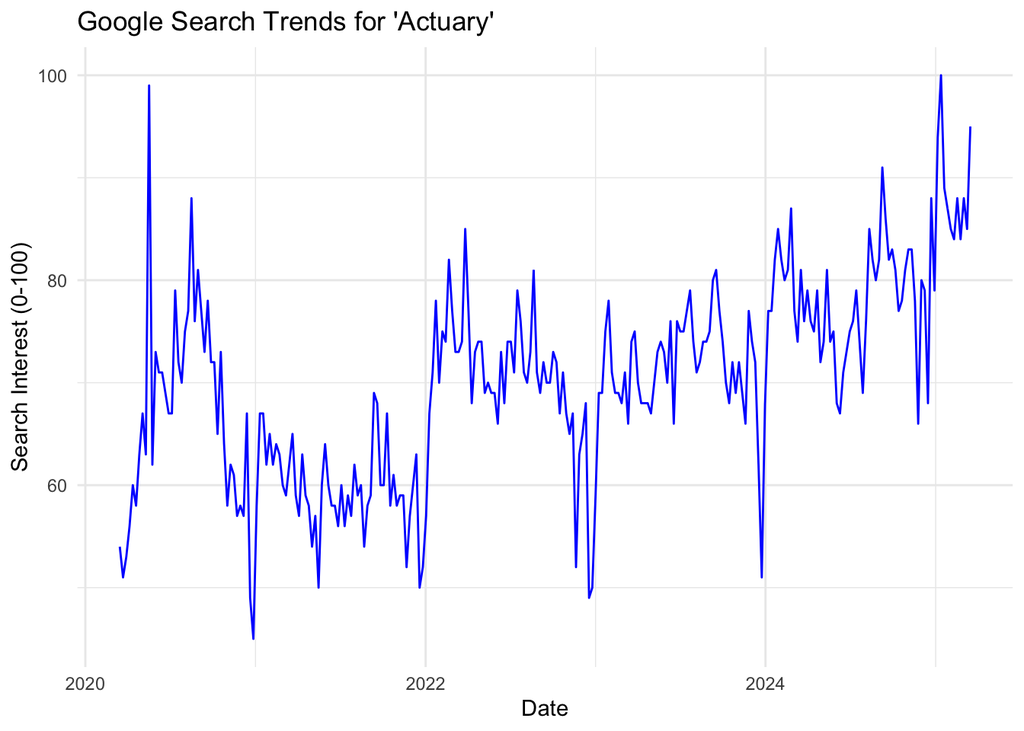

```r
library(ggplot2)
ggplot(actuary, aes(x = ds, y = y)) +
  geom_line(color = "blue") +
  labs(title = "Google Search Trends for 'Actuary'",
       x = "Date",
       y = "Search Interest (0-100)") +
  theme_minimal()
```

For more details on the data, please view the Actuary Search Trends in the UK Past 5 Years by clicking below https://trends.google.com/trends/explore?date=now%207-y&geo=GB&q=Actuary

Below are some images from Google trends that further illustrates the Interest over Time and Subregion:

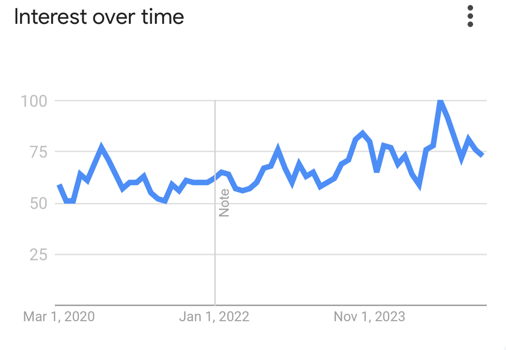

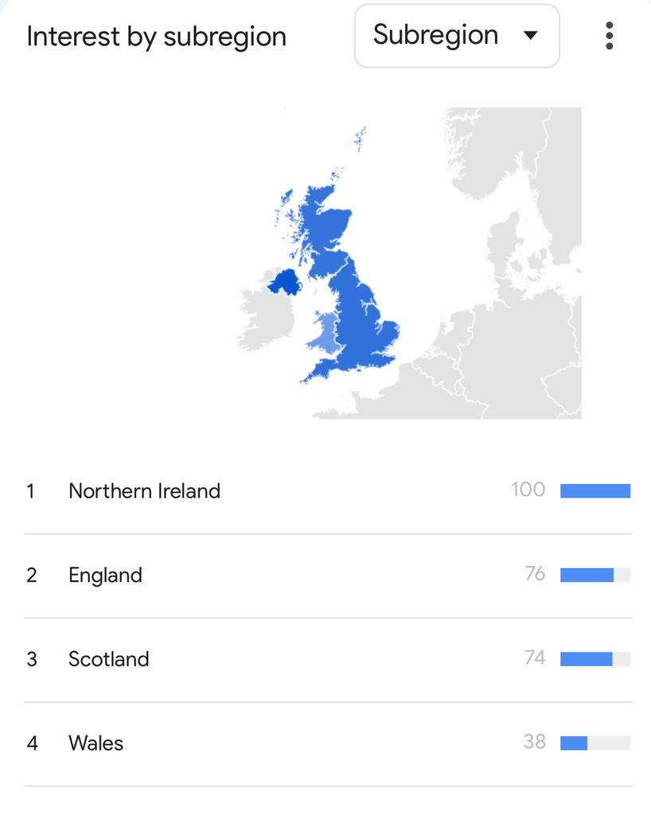

Interest Over Subregion

# Forecasting with Prophet

To forecast future search interest, I applied the Prophet model to the historical data. The following code fits the model and generates a forecast for the next 30 days.

```r
library(prophet)
# Fitting the Prophet model on the actuary data
model <- prophet(actuary)
```

```
## Disabling weekly seasonality. Run prophet with weekly.seasonality=TRUE to override this.
```

```
## Disabling daily seasonality. Run prophet with daily.seasonality=TRUE to override this.
```

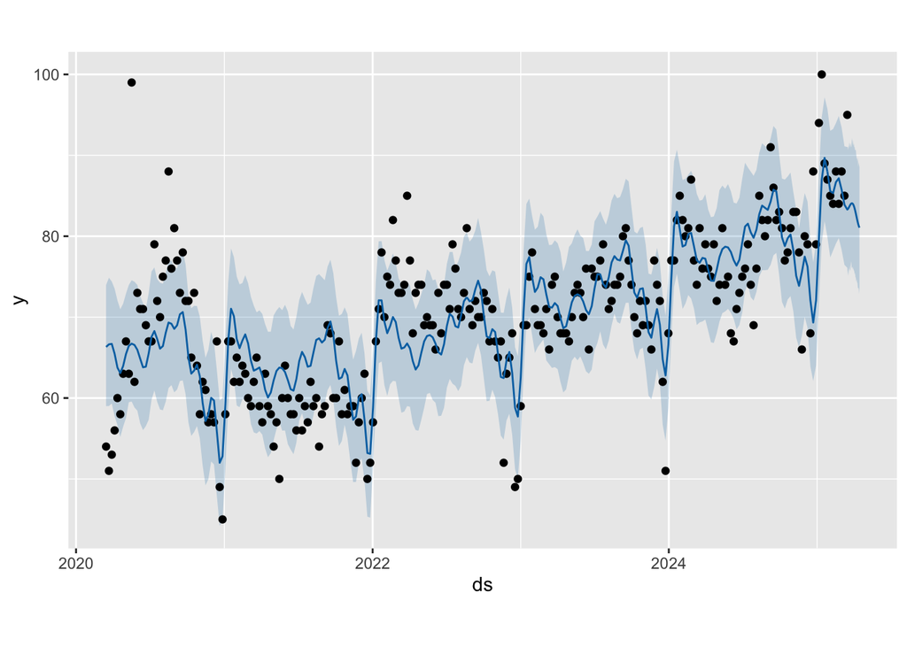

```r
# To Create a future dataframe for the next 30 days
future <- make_future_dataframe(model, periods = 30, freq = "day")

# To Generate the forecast
forecast <- predict(model, future)

# To Plot the forecast
plot(model, forecast)
```

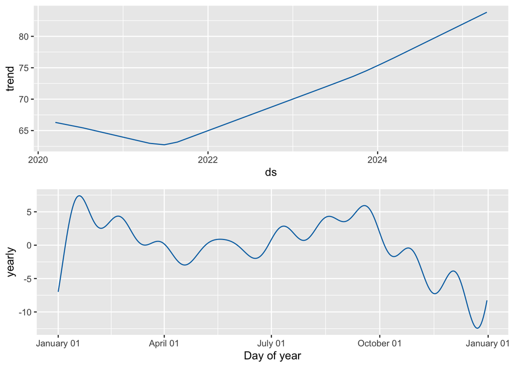

```r
#To Plot Forecast Components(trend,seasonality etc)
prophet_plot_components(model, forecast)
```

```r
# Convert date to numeric (number of days since the first observation)
actuary <- actuary %>%
  mutate(days = as.numeric(ds - min(ds)))

# Run a simple linear regression on the growth of search interest over time
growth_model <- lm(y ~ days, data = actuary)
summary(growth_model)
```

```
##
## Call:
## lm(formula = y ~ days, data = actuary)
##
## Residuals:
##     Min      1Q  Median      3Q     Max
## -24.229  -5.107  -0.121   4.307  37.982
##
## Coefficients:
##              Estimate Std. Error t value Pr(>|t|)
## (Intercept) 6.034e+01  9.691e-01   62.26   <2e-16 ***
## days        1.080e-02  9.179e-04   11.77   <2e-16 ***
## ---
## Signif. codes:  0 '***' 0.001 '**' 0.01 '*' 0.05 '.' 0.1 ' ' 1
##
## Residual standard error: 7.866 on 260 degrees of freedom
## Multiple R-squared:  0.3474, Adjusted R-squared:  0.3449
## F-statistic: 138.4 on 1 and 260 DF,  p-value: < 2.2e-16
```

This regression helps to quantify the average increase (or decrease) in search interest per day.

# Conclusion

This analysis demonstrates how Google search trends for “Actuary” can be used to gauge public interest over time. The data visualization reveals clear trends and seasonal patterns, while the Prophet model forecasts future search interest. Additionally, the linear regression analysis provides insight into the overall growth trend. These findings are valuable for understanding shifts in career interest within the actuarial field.

# References

Google Trends: https://trends.google.com

Prophet Documentation: https://facebook.github.io/prophet/docs/quick_start.html